# Honesty at the Margin

Eastern Economic Association 2018

## Context

Evidence in experimental and behavioral economics suggests the following:

- people have a *preference* for honesty (or against guilt or lying)
  - see Gneezy (2005), Gneezy et al (2013), Dreber & Johannssen (2010), Kartik (2009), and many others
- people have a utility function with standard properties
  - they have *social preferences* because they *dislike* lying
  - lying imposes a utility cost
  - **extensive margin**: cost to lying *at all*
  - **intensive margin**: cost in *size* of lie

## Lying in the real world?

But there's lots of evidence of people lying for profit

- people lied about MBS and CDOs prior to the financial crisis
- financial advisers who are *not* fiduciaries
- medical professionals who benefit from prescribing certain drugs
- lawyers displaying prosecutorial dishonesty
- current political climate?
  - do politicians who lie crowd out those who are unwilling (or are *as* unwilling) to do so?
  - what does this do to the market for politicans?

## Motivating questions & gaps in literature

- If honesty is preference-based, how vulnerable are the preferences to institutional setting?
  - Do preferences override setting, or are preferences context-dependent?
- How do people respond to **competition**?
- Can competition encourage/discourage full deception rather than merely 'disguised' lies (FFH, 2013)?
- How do outside offers affect choices to compete & to lie?
- Do people select into honest settings?
- Do people adapt to deception and lie more? (Garrett et al, 2016)

## Design Context

Fischbacher & Föllmi-Heushi (JEEA, 2013)

- dice-throwing game to measure *aggregate* deception.
- subjects roll a 6-sided die and report roll
- Roll 6 \(\Rightarrow\) CHF 0
- Roll \(1 \rightarrow 5 \Rightarrow\) equivalent CHF
- Honesty \(\Rightarrow\) with large \(n\), should be a uniform distribution \(U \sim [0, 5]\)

## For example…

[interactive chart not shown]

## FFH's Results

[interactive chart not shown]

## FFH Continued

- also a "high-stakes" treatment
  - subjects were paid CHF3 per pip reported up to CHF15
- all one-shot
- Experiment run after others (add-on)
- Repeat ubjects more likely to report a higher number the second time.
  - do we 'learn to lie'?

## Extension: D & K (2017)

Dannenberg and Khachatryan (2017, working paper)

- replicate FFH + "competition" + group decisions
- one-shot competitive choice
  - 1 vs. 1, or
  - in team of 3 vs. team of 3, or
  - 1 vs team of 3

## Extension: D & K (2017)

- 1 vs. 1: subjects *no more dishonest* than subjects who do not compete
- 3 vs. 3: more likely to report higher numbers (are more dishonest)
- Pace: Charness & Sutter (2013) – groups make "more self-interested" decisions

## Gaps left by FFH, D & K?

- Subjects in a "competitive" treatment have no choice about competing
- Group vs. individual not that interesting to us
- D & K have no opportunity to "learn to lie"
- If a subject cannot choose *not* to compete, is it really a *choice to compete*?
- What is the role of an outside offer/opportunity cost?
- What about the margins of:
  - choosing to compete and
  - reports of those who compete conditional on having chosen to compete?

## Baseline: Competition with high outside offer

- Each session has four groups of 6 subjects
- Choice of two tasks, A or B.

Task A:

- If A is chosen, subject reports a 10-sided die roll, which is compared to balls in an urn:
  - **40 even balls, 40 odd balls, 5 both, 15 neither balls**.
  - If die report matches odd/even get paid $15.
  - Otherwise payment is $5.00.

## Baseline: Competition with high outside offer

Task B:

- If B is chosen, the subject reports a 10-sided die roll.
  - Roll compared with another player's reported 10-side die roll.
  - If higher, player obtains $15; if lower, then $5, 50-50 on a tie.

## Design: T2 - Competition with Low Outside Offer

- Each session has four groups of 6 subjects
- Choice of two tasks, A or B.
- If A is chosen, subject reports a 10-sided die roll, which is compared to balls in an urn:
  - **20 even balls, 20 odd balls, 5 both, 55 neither balls.**
  - If the report matches odd/even get paid $15.
  - Otherwise payment is $5.00.
- Task B remains as in Group High

## Our design (HLW, contd.)

T3: Fair (Decision Problem)

- Same baseline Task A as in Group High A
- If B is chosen, the subject reports a 10-sided die roll.
  - Roll compared with a computer-rolled 10-side die with each number equally likely to be chosen.
  - If higher, player obtains $20 ($15), if lower $5; 50-50 chance on a tie.

## Our design (HLW, contd.)

Additional details

- Subject repeats their choice 30 times.
- We observe the margin of choosing Tasks A or B (extensive)
- On choosing B, we measure the distribution of reports (intensive because repeated within subject)
- Contrast with theoretical distribution and across treatments

## Summary of Treatments

| Treatment | Task A | Task B | n | Mean Earnings |
| --- | --- | --- | --- | --- |
| High A | High outside offer | Other subject | 48 | 21.04 |
| Low A | Low outside offer | Other subject | 24 | 19.58 |
| Individual | High outside offer | Fair computer | 24 | 22.5 |

## Basic Summary Statistics

| Variable | Mean/Proportion | Std. Dev |
| --- | --- | --- |
| Average Roll | 6.061 | 2.923 |
| Proportion Competitive | 0.514 | 0.5 |
| Average Roll For Task A | 4.608 | 2.746 |
| Average Roll for Task B | 7.436 | 2.368 |

## Potential behaviors (randomized n = 100 rolls)

[interactive chart not shown]

## Preliminary Results

- Competition increases deception
- Offering honest people a decent outside offer reduces their selection into the competitive task
- With low outside offers, more people deceive on the extensive, but deception on the intensive margin is lower
  - honest types don't want to deceive quite as much
- Less deception in the decision environment

## Average rolls by choice

[interactive chart not shown]

## Rolls by Treatment

[interactive chart not shown]

## Scatterplot By Treatment

[interactive chart not shown]

## Histogram by treatment

[interactive chart not shown]

## Tasks by Group and Distance from Uniform

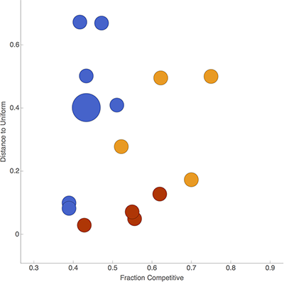

## Groups with Task A

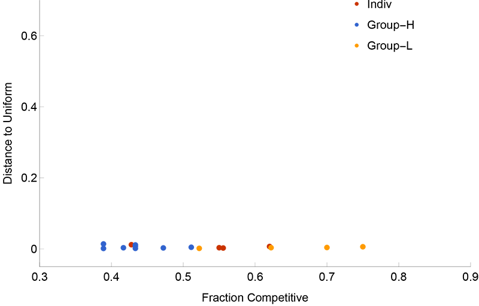

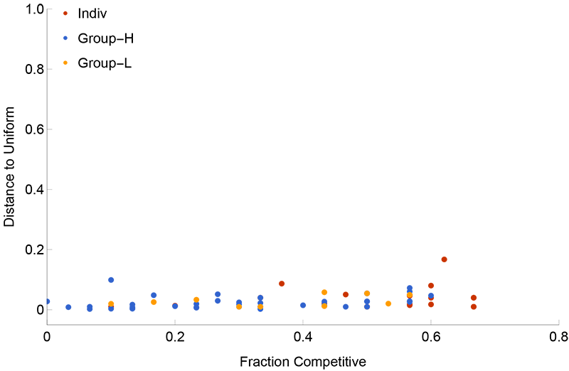

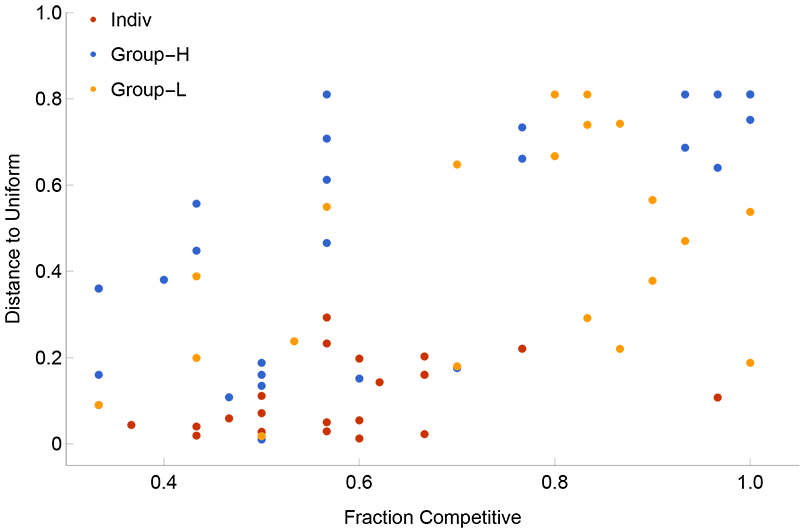

## Preliminary Regression Analysis: Panel Model

For individual \(i\) in group \(g\) and period \(t\): \[P[\mbox{Choose B = 1}]_{igt} = \beta_0 + \beta_1\cdot T_{ig} + \beta_2 Trend + \epsilon_{igt}\] Regressions include the treatment dummies and, in the second specification, trend dummies.

## Regression Results

|  | Pr. Chose Competitive Task (Task B) |  |
| --- | --- | --- |
|  | Basic | With Trend |
| Group (High A) | -0.10*** | -0.10*** |
|  | (0.02) | (0.02) |
| Group (Low A) | 0.11*** | 0.11*** |
|  | (0.03) | (0.03) |
| Constant | 0.54*** | 0.50*** |
|  | (0.02) | (0.03) |
| Observations | 2,880 | 2,880 |
| Adjusted R<sup>2</sup> | 0.03 | 0.03 |
| Notes: | Panel LPM. |  |
|  | ***Significant at the 1 percent level |  |

## How do the sessions conclude?

[interactive chart not shown]

## Conclusions and contributions?

- Measure margins not previously measured
- Repeated choices \(\Rightarrow\) learning
  - others have been one-shot
- Task is short with a high payoff (incentive compatible)
- Extensions
  - experiment to examine demand and supply of deception
  - what happens if hiring decisions are based on report? \(\uparrow\) or \(\downarrow\) deception?

## Further treatments: Deceptive Computer

- Same as T1, except computer has a die with 9 faces = 9 and 1 = 0.
- 50-50 chance of prize if reporting 9.
- Why? Upper-bound limit on those who want the 50-50 lottery if they are guaranteed to lie.
- How do we constrain, if at all, deceptive types?